# NYPD Shootings EDA

Phillip Hughes

2023-12-31

# First we get our packages and Data

We will be using the tidyverse

```r
library(tidyverse)
```

We will be importing the NYC_Shooting_Data into our Rmarkdown file.

```r
NYPD_Shooting_Incident_Data_Historic_ <- read_csv("NYPD_Shooting_Incident_Data__Historic_.csv")
NYPD_Shooting_Incident_Data_Historic_
```

```
## # A tibble: 27,312 × 21
##    INCIDENT_KEY OCCUR_DATE OCCUR_TIME BORO     LOC_OF_OCCUR_DESC PRECINCT
##           <dbl> <chr>      <time>     <chr>    <chr>                <dbl>
##  1    228798151 5/27/2021  21:30      QUEENS   <NA>                   105
##  2    137471050 6/27/2014  17:40      BRONX    <NA>                    40
##  3    147998800 11/21/2015 03:56      QUEENS   <NA>                   108
##  4    146837977 10/9/2015  18:30      BRONX    <NA>                    44
##  5     58921844 2/19/2009  22:58      BRONX    <NA>                    47
##  6    219559682 10/21/2020 21:36      BROOKLYN <NA>                    81
##  7     85295722 6/17/2012  22:47      QUEENS   <NA>                   114
##  8     71662474 3/8/2010   19:41      BROOKLYN <NA>                    81
##  9     83002139 2/5/2012   05:45      QUEENS   <NA>                   105
## 10     86437261 8/26/2012  01:10      QUEENS   <NA>                   101
## # ℹ 27,302 more rows
## # ℹ 15 more variables: JURISDICTION_CODE <dbl>, LOC_CLASSFCTN_DESC <chr>,
## #   LOCATION_DESC <chr>, STATISTICAL_MURDER_FLAG <lgl>, PERP_AGE_GROUP <chr>,
## #   PERP_SEX <chr>, PERP_RACE <chr>, VIC_AGE_GROUP <chr>, VIC_SEX <chr>,
## #   VIC_RACE <chr>, X_COORD_CD <dbl>, Y_COORD_CD <dbl>, Latitude <dbl>,
## #   Longitude <dbl>, Lon_Lat <chr>
```

## Tidying

I will only focus on Borough, Dates, Victims and if the victim died.

```r
NYC_Shootings_Boro<- NYPD_Shooting_Incident_Data_Historic_ %>%
  select(c(OCCUR_DATE, BORO, STATISTICAL_MURDER_FLAG, VIC_AGE_GROUP, VIC_SEX, VIC_RACE)) %>%
    mutate(OCCUR_DATE=mdy(OCCUR_DATE),
         YEAR = year(OCCUR_DATE),
         MONTH=month(OCCUR_DATE))
head(NYC_Shootings_Boro)
```

```
## # A tibble: 6 × 8
##   OCCUR_DATE BORO    STATISTICAL_MURDER_F…¹ VIC_AGE_GROUP VIC_SEX VIC_RACE  YEAR
##   <date>     <chr>   <lgl>                  <chr>         <chr>   <chr>    <dbl>
## 1 2021-05-27 QUEENS  FALSE                  18-24         M       BLACK     2021
## 2 2014-06-27 BRONX   FALSE                  18-24         M       BLACK     2014
## 3 2015-11-21 QUEENS  TRUE                   25-44         M       WHITE     2015
## 4 2015-10-09 BRONX   FALSE                  <18           M       WHITE H…  2015
## 5 2009-02-19 BRONX   TRUE                   45-64         M       BLACK     2009
## 6 2020-10-21 BROOKL… TRUE                   25-44         M       BLACK     2020
## # ℹ abbreviated name: ¹STATISTICAL_MURDER_FLAG
## # ℹ 1 more variable: MONTH <dbl>
```

# Visualization

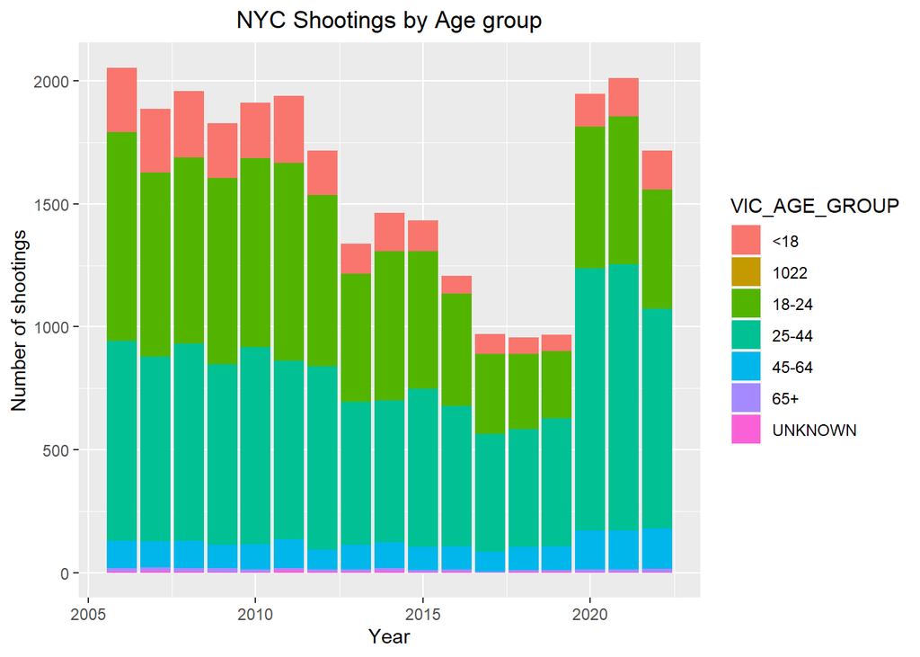

```r
NYC_Shootings_Boro %>% ggplot(aes(x=YEAR, fill = VIC_AGE_GROUP))+
  geom_bar()+
  ggtitle("NYC Shootings by Age group")+
  theme(plot.title = element_text(hjust = 0.5))+
  xlab("Year")+
  ylab("Number of shootings")
```

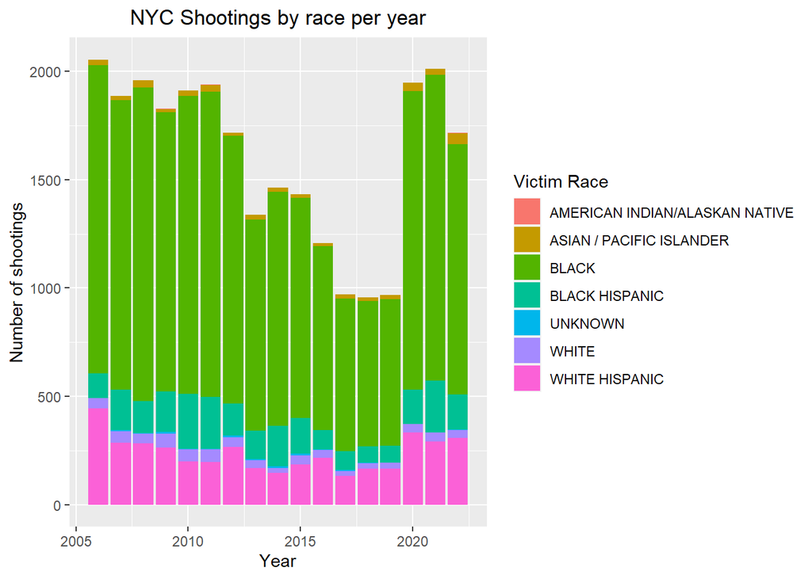

```r
NYC_Shootings_Boro %>% ggplot(aes(x=YEAR, fill=VIC_RACE))+
  geom_bar()+
  ggtitle("NYC Shootings by race per year")+
  theme(plot.title = element_text(hjust = 0.5))+
  xlab("Year")+
  ylab("Number of shootings")+
  guides(fill=guide_legend(title="Victim Race"))
```

This shows that Black individuals are at a higher chance of being the victim of a shooting by a disproportional ammount. There are many factors that might impact why this is. Bu t further data would be needed.

```r
Murders <- NYC_Shootings_Boro %>% group_by(YEAR,BORO,STATISTICAL_MURDER_FLAG) %>% summarise(Murders = sum(STATISTICAL_MURDER_FLAG), Non_Fatal_Shootings = table(STATISTICAL_MURDER_FLAG))
Murders<-Murders %>% mutate(Shootings=sum(Non_Fatal_Shootings), Murder_Percent= 100* Murders/Shootings)
Murders<- Murders[Murders$Murders !=0,]
Murders<- Murders %>% select(-c(Non_Fatal_Shootings,STATISTICAL_MURDER_FLAG))
Murders
```

```
## # A tibble: 85 × 5
## # Groups:   YEAR, BORO [85]
##     YEAR BORO          Murders Shootings Murder_Percent
##    <dbl> <chr>           <int>     <int>          <dbl>
##  1  2006 BRONX             137       568           24.1
##  2  2006 BROOKLYN          176       850           20.7
##  3  2006 MANHATTAN          60       288           20.8
##  4  2006 QUEENS             59       296           19.9
##  5  2006 STATEN ISLAND      13        53           24.5
##  6  2007 BRONX              93       533           17.4
##  7  2007 BROOKLYN          177       833           21.2
##  8  2007 MANHATTAN          46       233           19.7
##  9  2007 QUEENS             48       238           20.2
## 10  2007 STATEN ISLAND       9        50           18
## # ℹ 75 more rows
```

So I set up a new table to compare shooting totals to number that resulted in murder to see if there was a change i murder percent between years. But it appears that there is not a change in Murder over the years.

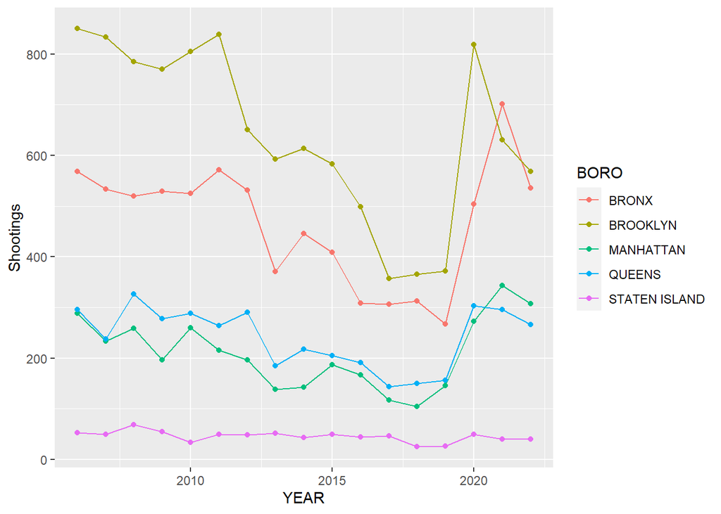

```r
Murders %>% ggplot(aes(x=YEAR, y=Shootings, group=BORO))+
  geom_line(aes(color=BORO))+
  geom_point(aes(color=BORO))
```

this graph shows shootings by boroughs throughout the years data has been collected. Staten Island has been sort of an outlier as the number of shootings has remained relatively low. For the rest of the Burroughs there was a decrease from 2006 to 2019. Then a sharp increase between 2019 and 2020. and has gone down from 2021 to 2022.

# Potential Bias

I believe there is bias in what this data shows because it doesnt take into account population percent that were confined to their neighborhoods in 2019-2022 during the pandemic. I think theree would be a more complete picture to be had if there was data included that represented this issue.